## DATA SCIENCE SPECIALISM

### CAPSTONE PROJECT (2016 JUNE - JULY)

## Building an English predictive language data product

## The Milestone Report

### INTRODUCTION

The advent of the internet, its software and now mobile applications has spawned the need for predictive text algorithms. For those with physical and speech disabilities (e.g. Professor Stephen Hawking) predictive text speech programmes are the basis of their talking computers.

This milestone report aims to address the objectives of the Data Science Specialism Capstone Module, which is to write a predictive language (text mining) data product using three supplied text files: U.S. blogs, U.S. news and U.S. twitter which can be downloaded from this link: https://d396qusza40orc.cloudfront.net/dsscapstone/dataset/Coursera-SwiftKey.zip.

Guided by the six tasks set in Weeks 1 & 2:-

1. To tokenization each text file;
2. Profanity filtering;
3. Exploratory data analysis;
4. Understand the frequencies of words and word pairs;
5. Build a basic N-gram model;
6. Build a model to handle unseen N-grams;

the first part of this project elucidates the statistics of each dataset.

Second how big a population sample is required from each dataset in order to produce fairly accurate text prediction algorithm.

And finally generate tables and/or graphics for each of the datasets to discover the most frequent words and word pairs.

### DATA EXPLORATION

I loaded the relevant R libraries and checked that they were installed using the sessionInfo() command. I used the doParallel package to use all CPU cores for speedier computation power. I also called the set.seed command to reproduce time and time again a fixed population sample for each dataset.

```r
##1 - LOADING LIBRARIES
library(doParallel); library(tm); library(stringi); library(RWeka); library(wordcloud); library(knitr); library(rmarkdown)

    ##2 - WHAT HARDWARE/SOFTWARE IS BEING USED?
    #sessionInfo()

        ##3 - USING ALL THE CPU'S
        CPU <- parallel::detectCores()
        registerDoParallel(makeCluster(CPU))

            ##4 - REPRODUCIBLITY
            set.seed(12970)
```

Loading the files into the R package was problematic as this threw up reading errors. This was especially true for the news dataset where four lines (numbers 77259, 776277, 926143 and 948564) would stop the download at that particular line. The cause of this stoppage was the word SUB inside a black block. This word was removed manually from the news file en_US.news.txt using the Notepad++ package.

```r
#5 - LOADING THE DATASETS
blog <- readLines("en_US.blogs.txt", encoding = "UTF-16")
news <- readLines("en_US.news.txt", encoding = "UTF-16")
twitter <- readLines("en_US.twitter.txt", encoding = "UTF-16")
```

Summary statistics for each dataset are:

```r
    ##6.5 - SUMMARY TABLE
    data.frame(dataset = c("blog", "news", "twitter"), filesize.MB = c(blogmbsize, newsmbsize, twittermbsize), number.of.lines = c(bloglength, newslength, twitterlength), total.no.characters = c(blogcharacter, newscharacter, twittercharacter), max.no.characters.line = c(blogmaxchar, newsmaxchar,  twittermaxchar), mean.no.characters.line = c(blogmeanchar, newsmeanchar, twittermeanchar), max.no.words = c(totalblogwords, totalnewswords, totaltwitterwords),  mean.no.words.line = c(meanblogwords, meannewswords, meantwitterwords))
```

```
##   dataset filesize.MB number.of.lines total.no.characters
## 1    blog    200.4242          899288           208361438
## 2    news    196.2775         1010242           203791402
## 3 twitter    159.3641         2360148           162385035
##   max.no.characters.line mean.no.characters.line max.no.words
## 1                  40835                231.6960     38154238
## 2                  11384                201.7253     35010784
## 3                    213                 68.8029     30218166
##   mean.no.words.line
## 1           42.42716
## 2           34.65584
## 3           12.80350
```

How big a population size should I use? With the large file sizes and limited computation power I took a 5% random sample of the total number of lines for each dataset.

```r
##7 - TAKING A RANDOM SUBSET OF EACH DATASET
##at 5% of each file initially all dependent on the speed of my laptop

datasetblog <- sample(blog, (5/100 * length(blog)), replace = FALSE)
datasetnews <- sample(news, (5/100 * length(news)), replace = FALSE)
datasettwitter <- sample(twitter, (5/100 * length(twitter)), replace = FALSE)
```

Preprocessing of the dataset required removing rude words, numbers, extra spaces, punctuation and symbols. I also removed stopwords. These 174 words are common words that provide no informative information in respect of data analysis. Example words are: and, to, I, the, from, where, had, there. All words were changed to lower case to reduce word duplication through usage of different capitalisation in all words.

To discover word frequencies and word pairs each dataset was transformed into a corpus and then a term document matrix.

```r
##9 - CREATING CORPII
corpusblog <- Corpus(VectorSource(datasetblog))
corpusnews <- Corpus(VectorSource(datasetnews))
corpustwitter <- Corpus(VectorSource(datasettwitter))

    ##10 - CREATING A TERM DOCUMENT MATRIX
    tdmblog <- TermDocumentMatrix(corpusblog)
    tdmnews <- TermDocumentMatrix(corpusnews)
    tdmtwitter <- TermDocumentMatrix(corpustwitter)

    dtmblog <- DocumentTermMatrix(corpusblog)
    dtmnews <- DocumentTermMatrix(corpusnews)
    dtmtwitter <- DocumentTermMatrix(corpustwitter)
```

Words that occur more than 2000 times for blog, news and twitter datasets respectively:

```
## [1] "â"    "back"   "day"    "good"   "love"   "make"   "people" "time"
```

```
## [1] "â"    "people" "state"  "time"   "year"   "years"
```

```
##  [1] "back"    "day"     "dont"    "follow"  "good"    "great"   "happy"
##  [8] "lol"     "love"    "make"    "night"   "people"  "time"    "today"
## [15] "tonight" "work"
```

Word pairs with the highest correlation values. These are blog: love, day, time. For news: years, year. For twitter: happy, day, good.

The duplication of years and year can be removed by stemming words, i.e. removing word endings such as s, ing, tive, lly.

```
## $love
##           depress         metropark            volare               baa
##              0.28              0.28              0.28              0.20
##           bloomed       dangerfield extraterrestrials            puppys
##              0.20              0.20              0.20              0.20
##          redwoods            sultry             chirp         premiered
##              0.20              0.20              0.16              0.16
##      âfreedomâ          ânotâ   âobligationâ              meow
##              0.15              0.15              0.15              0.15
##          brandnew              ella          withered         dinosaurs
##              0.14              0.14              0.14              0.12
##       marshmallow          canceled             ellas          galaxies
##              0.12              0.11              0.11              0.11
##      gratefulness
##              0.10
```

```
## $day
##         valentines      outregardless            refocus
##               0.15               0.13               0.13
##            mothers               time      âsaraswathi
##               0.11               0.11               0.10
## âvijayadashamiâ          amavaasai             ayudha
##               0.10               0.10               0.10
##       daysdusshera              durga              kriya
##               0.10               0.10               0.10
##            lakshmi           mahalaya           parvathy
##               0.10               0.10               0.10
##               puja             pujaâ          purattasi
##               0.10               0.10               0.10
##           ritually         saraswathi    saraswathignana
##               0.10               0.10               0.10
##            shakthi
##               0.10
```

```
## $time
##        aaâ     allstate  animalistic        bodes        botch
##         0.14         0.14         0.14         0.14         0.14
##   brutalised  brutalising         cena      cenaâ     cenaless
##         0.14         0.14         0.14         0.14         0.14
##  chainloaded       lesnar    lesnarâ         maul          mma
##         0.14         0.14         0.14         0.14         0.14
##      quashed    supercena sympathising   threecount   turnbuckle
##         0.14         0.14         0.14         0.14         0.14
##        spend         long        apron          day        match
##         0.13         0.12         0.11         0.11         0.11
##     overshot       comers   emblematic    grappling       kimura
##         0.11         0.10         0.10         0.10         0.10
##      swarmed welldeserved
##         0.10         0.10
```

```
## $years
##  ago past
## 0.26 0.11
```

```
## $year
##        accardi        amarjit        baljeet       belabbas        ephrata
##           0.14           0.14           0.14           0.14           0.14
##          fatra         grewal       inderjit         jassal      jaswinder
##           0.14           0.14           0.14           0.14           0.14
##      kulwinder      myerstown northumberland        ranshaw      richfield
##           0.14           0.14           0.14           0.14           0.14
##        slimane        million          singh
##           0.14           0.11           0.10
```

```
## $happy
## birthday  mothers      day
##     0.35     0.19     0.13
```

```
## $day
##    mothers      happy valentines
##       0.24       0.13       0.12
```

```
## $good
##    luck morning
##    0.21    0.17
```

As a wordcloud the most popular 250 words for blog and news datasets respectively:

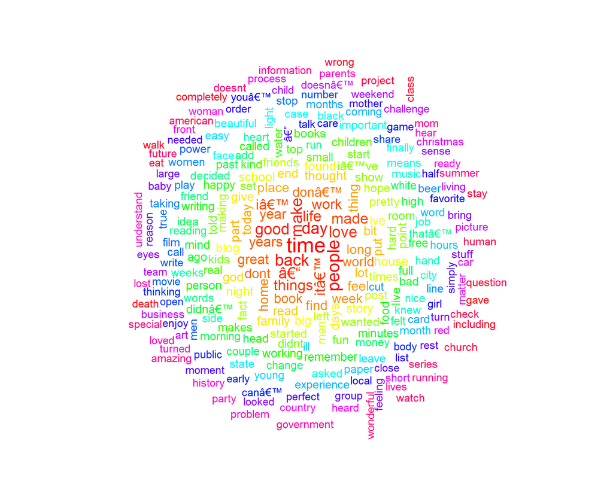

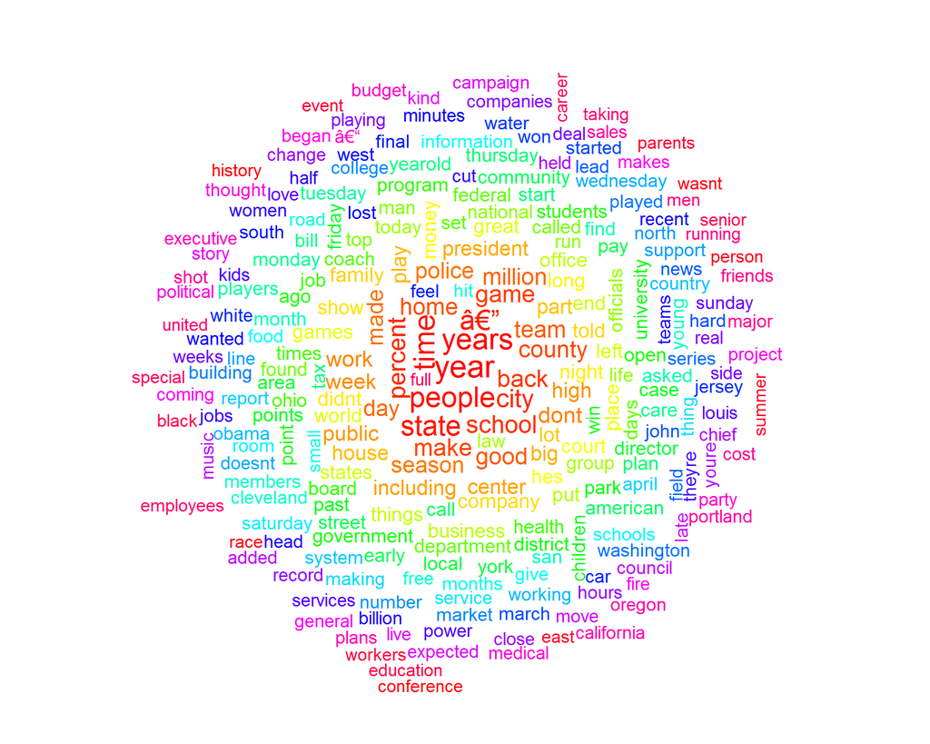

The most popular 250 twitter words:

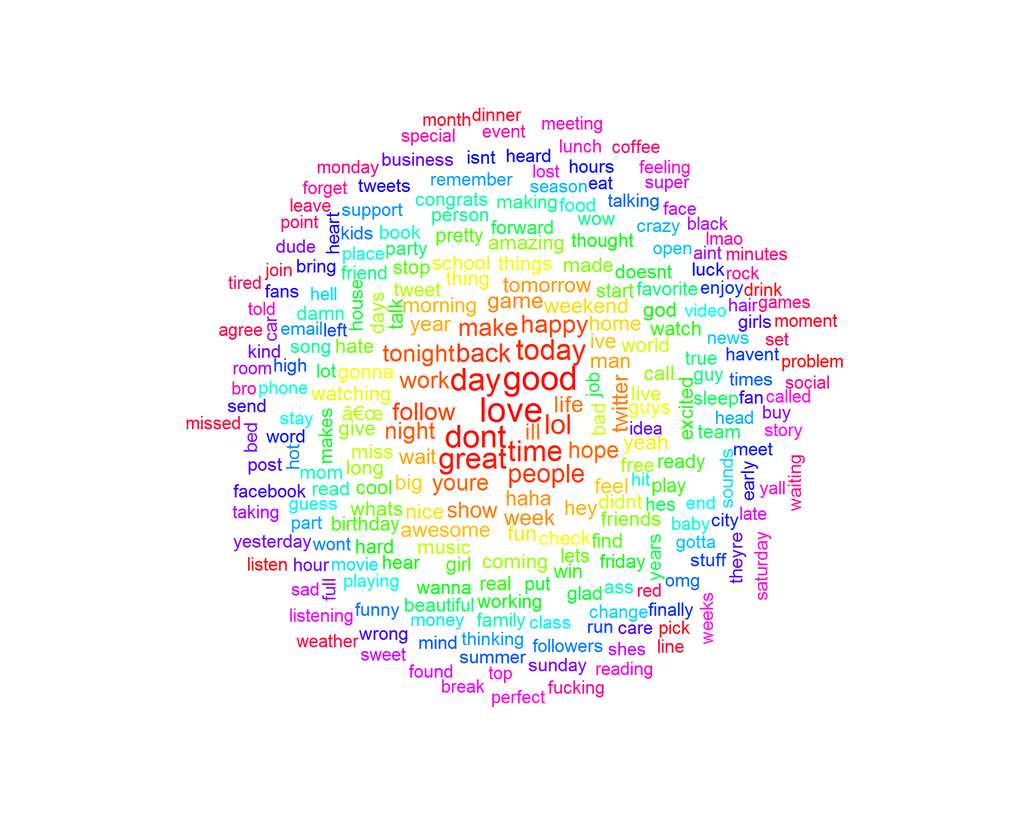

### WORD PREDICTION ALGORITHM PRODUCTION

Symbols are still occurring in the tables and wordclouds and not been effectively removed using the removePunctuation command. I will have to remove them using the gsub command instead.

The coding will need to be reduced to allow prediction algorithm to run faster. This will be accomplished by creating saved files from the original datasets and preprocessing analysis.

The next stage is to produce N-grams for each of the three datasets as basis to calculate each word probability for usage by the final predictive word algorithm run inside a Shiny app.

How many words should the N-gram algorithm use to accurately predict words? It is suggested that trigrams are most effective, but is that the case? I will try bigrams, trigrams, quadgram and pentagrams.

How can I predict unseen N-grams? My current thoughts are to use hidden markov models commands.

I am thinking of using the ngram package rather than the tm package to fulfill the above objectives.

For the Shiny app to work I need to create two documents server.R and ui.R. There must be input and output text boxes to predict words. Should the output be one word or several? I am thinking that the output should show 5 words. Should there be one combined dataset or three separate datasets for word prediction?

I have much to think about in order to write an effective Shiny app.